# Local Statistics: Finding the Uniqueness in All of Us

# Stressing the Local

Today, we’re going to look at *local spatial autocorrelation*. Like a kind of *outlier* diagnostic, local spatial autocorrelation measures how the *local* structure of a spatial relationship around each site either conforms to what we expect or is different from what we expect. Together, *local* spatial statistics are a general branch of statistics tha aim to characterize the relationship between *a single observation* and the sites surrounding it.

Often, *local* spatial autocorrelation is contrasted with *global* spatial autocorrelation, which is the structural relationship between *sites* (in abstract) and their *surroundings* (again, in abstract)., and this may have strongly different structure for many ideas of what *surrounds* each observation. Thus, local statistics are an attempt at measuring the geographical beahvior of a given social, physical, or behaviorial process around each observation.

```r
library(sf)
library(mosaic)
bristol = sf::st_read('./data/bristol-imd.shp')
```

# First, Correlation

First, though, let’s really refresh our understanding of plain, a-spatial *correlation*, and how our knowledge of outliers work in two dimensions for a standard relationship between two variables. Here, let’s look at the relationship between housing deprivation and crime in Bristol:

```r
correlation = cor.test(housing ~ crime, data=bristol)
correlation
```

```
##
##  Pearson's product-moment correlation
##
## data:  housing and crime
## t = 7.8199, df = 261, p-value = 1.309e-13
## alternative hypothesis: true correlation is not equal to 0
## 95 percent confidence interval:
##  0.3322359 0.5287749
## sample estimates:
##       cor
## 0.4356841
```

While there is some correlation between these two scores (areas with housing deprivation tend to have higher crime), we can *also* see that not every observation agrees with this trend. Namely, we can highlight one such observation with really low crime rates, but relatively high housing deprivation:

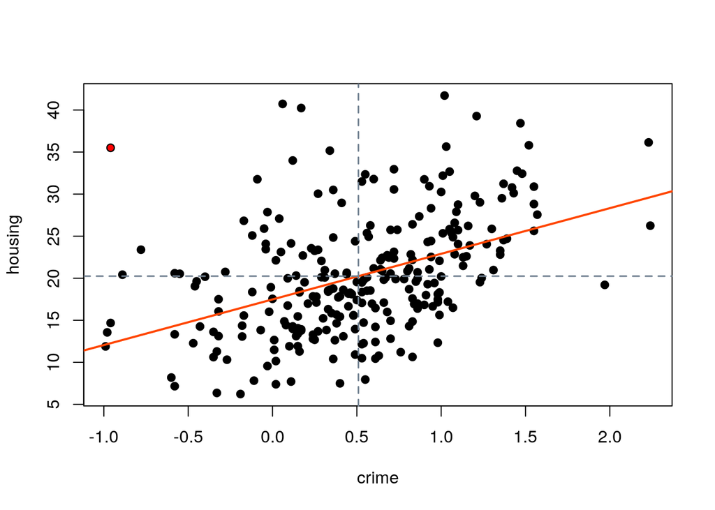

```r
plot(housing ~ crime, data=bristol, pch=19)
abline(lm(housing ~ crime, data=bristol),
       col='orangered', lwd=2)
abline(v=mean(bristol$crime), lwd=1.5, col='slategrey', lty='dashed')
abline(h=mean(bristol$housing), lwd=1.5, col='slategrey', lty='dashed')
housing_outlier = bristol[bristol$LSOA11CD == 'E01014714',]
points(housing_outlier$crime, housing_outlier$housing, col='red', pch=20)
```

## Challenge: Statistics as noise & distance

Humans do a few things they “see” outliers in a scatterplot. Mainly our intution about which observations are (visual) outliers comes from the distance between an observation and the center of the data being analyzed. This is why we are apt to think that the red observation is an outlier, but the blue may not be.

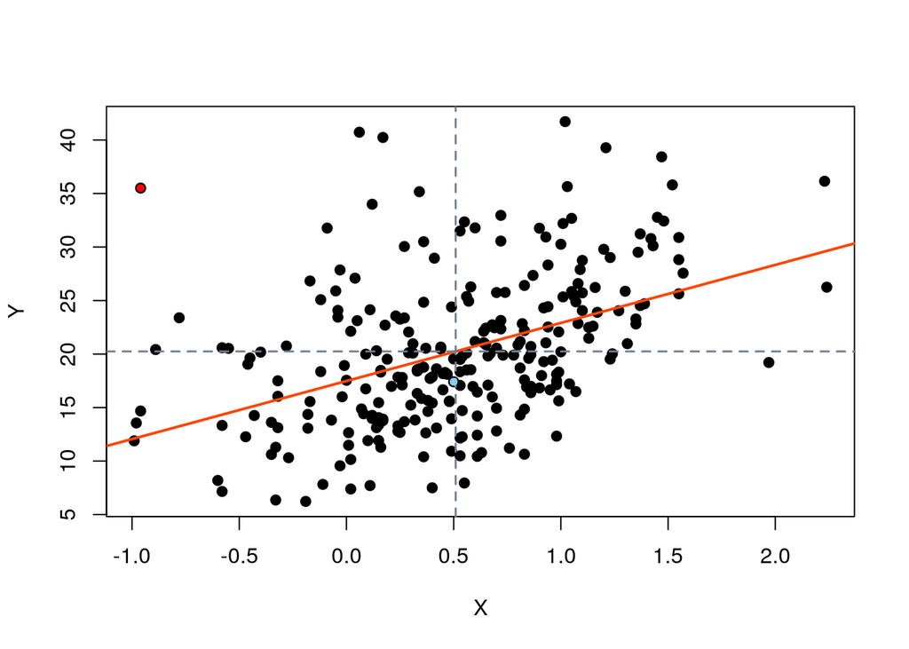

Fundamentally, this is because the data at our outlier site, $(x_i, y_i)$, is still very far away from the center of the point cloud, $(\bar x, \bar y)$, despite the variability and co-variability in the data. The co-variability matters greatly for how easy it is to detect outliers. For instance, it’s much easier for you to just “see” an outlier in this data:

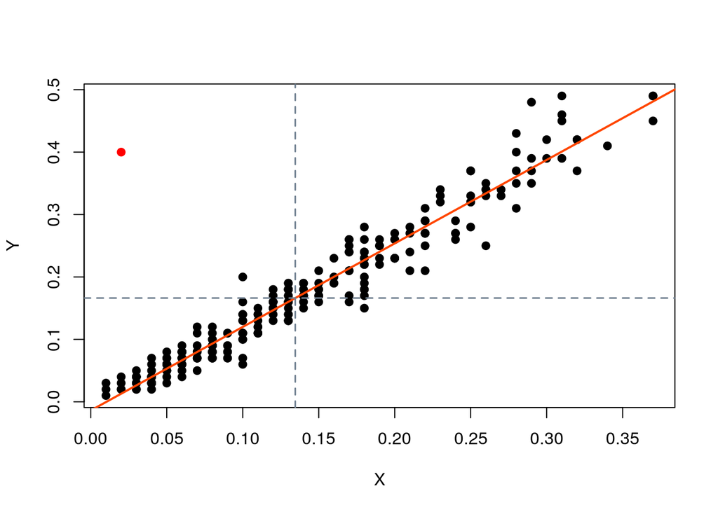

Than in this data:

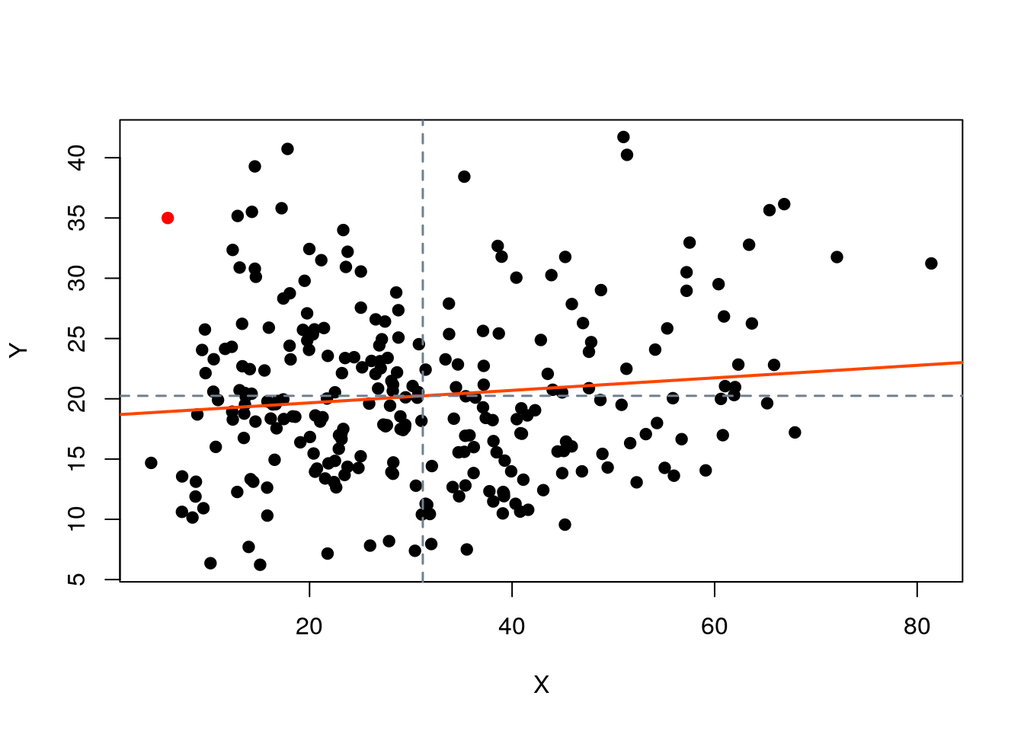

One way that we can mathematically model this idea of *extreme* values (those that are unlike other values) using the mean co-variance in our problem is to use another kind of variance-weighted distance. Recently, we worked with Cohen’s $d$, a *univariate* measure of the distance between two samples, standardized by the variance of the samples. Another measure of difference for 2 (or more) dimensional data is the [*Mahalanobis distance*](https://en.wikipedia.org/wiki/Mahalanobis_distance). This is a statistical distance that is defined as a weighted difference between observations and the “center” of the point cloud. The *weighting* is a function of the covariation between variables, and the “center” is the *mean* of each variable. The *Mahalanobis distance* itself measures *how far out of the point cloud* a given point is.

1. Another statistic we work with (first shown in Year 1) is *also* a variance-standardized distance. Can you recall which statistic this is?[^hint-tstatistic]
2. Compute the Mahalanobis distance in `R` using the following code:

```r
# Compute the mahalanobis distance:
just_data = sf::st_drop_geometry(bristol[c('housing','crime')])
housing_mean = mean(bristol$housing)
crime_mean = mean(bristol$crime)
mdistance = mahalanobis(just_data,
                        c(housing_mean, crime_mean),
                        cov(just_data))
```

Then, make a histogram of `mdistance`. Describe the distribution of Mahalanobis distances. Why might the distances be distributed this way if the Mahalnobis distance measures *how far out of the point cloud* each point is?[^1] 2. Make a scatterplot of the same `housing ~ crime` relationship we’ve seen before, but make each point’s color a function of the Mahalanobis distance we computed before. Below is the code (using `ggplot`, which we haven’t explicitly used yet) that can build the plot:

```r
# We'll use ggplot because it's easier for the coloring:
library(ggplot2)
# Start a ggplot
ggplot2::ggplot(bristol, aes(x=crime, y=housing, color=mdistance)) +
  # Then, add points at each x,y in (crime, housing)
  ggplot2::geom_point() +
  # add an "lm" smooth to the scatterplot with no standard error:
  ggplot2::geom_smooth(method='lm', se=FALSE) +
  # add a horizontal line at the average of housing
  ggplot2::geom_hline(yintercept = mean(bristol$housing)) +
  # add a vertical line at the average of crime
  ggplot2::geom_vline(xintercept = mean(bristol$crime)) +
  # use viridis colors instead of the default
  ggplot2::scale_color_viridis_c(option='plasma') +
  # and use a dark scheme so it's easier to see
  ggplot2::theme_dark()
```

3. Describe what the Mahalanobis distance shows in the scatterplot above. Do the colors in the plot conform to subjective interpretations of how “outlier-y” observations are with respect to the line of best fit plotted?
4. Make a map of the Mahalnobis distance[^2]. Do areas with large Mahalnobis distances tend to be near one another?

# Local Stats

The idea of observations that just *don’t fit* within an expected relationship or structure in our data takes special meaning in a geographical context. Given our existing explorations into *spatial autocorrelation*, measures of *local spatial autocorrelation* measure how outlier-y each observation is *from its surroundings*. In a similar manner to our previous dicsussions of outliers in a scatterplot, it is easy to develop a measure of *local spatial autocorrelation* from the Moran Scatterplot.

To get started, let us build `touches` weights, also known as *contiguity* weights for our data. This can be done quickly using the `spdep` package in `R`. Using `spdep`, we can build an object that contains all the information about which areas touch each other area:

```r
library(spdep)
touches = spdep::poly2nb(bristol)
# for some reason, spdep has many formats of weight:
touches = spdep::nb2listw(touches)
```

While before we used `sf` to build the `within_distance` relationships between every pair of observations manually, this function turns these kinds of requests into a handy function (that’s also substantially faster). We can compute a few different types of weights using `spdep`, and do so *way* faster than we did before:

```r
# All of the following are `nb` objects. Don't forget to convert them to listw!
within_2000m = spdep::dnearneigh(sf::st_centroid(bristol), 0, 2000)
within_4000m = spdep::dnearneigh(sf::st_centroid(bristol), 0, 4000)
nearest_10 = spdep::knearneigh(sf::st_centroid(bristol), k=10)
nearest_10 = spdep::knn2nb(nearest_10)
```

One common kind of *local* statistic used in spatial statistics relates to the Moran scatterplot.[^3] We can make this plot below in the way we did last practical:

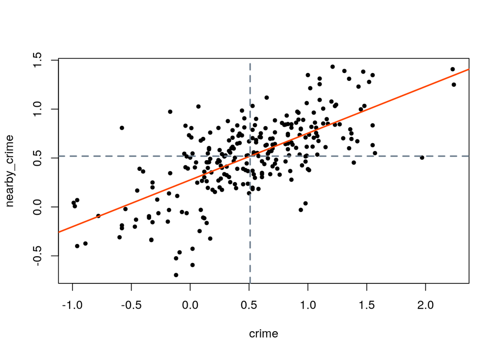

```r
nearby_crime = spdep::lag.listw(touches, bristol$crime)
bristol['nearby_crime'] = nearby_crime

plot(nearby_crime ~ crime, data=bristol, pch=20)
abline(lm(nearby_crime ~ crime, data=bristol), lwd=2, col='orangered')
abline(h=mean(bristol$nearby_crime), col='slategrey', lwd=2, lty='dashed')
abline(v=mean(bristol$crime), col='slategrey', lwd=2, lty='dashed')
```

And, this scatterplot corresponds to the map of `crime` in our data:

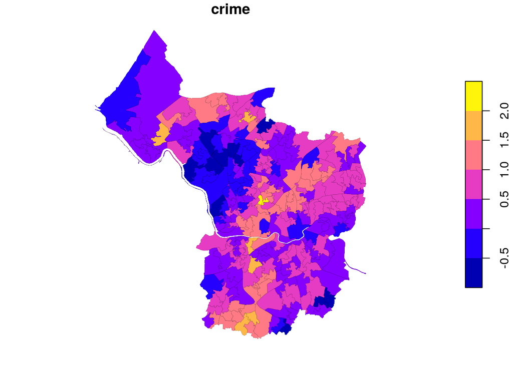

```r
plot(bristol['crime'], lwd=.1)
```

Recalling the *formula* of the line of best fit, we can express the relationship between the variable observed at sites $i$ and $j$ (spelled $x_i$ and $x_j$), as a function of the variability (and co-variability) of $x_i$ and $x_j$ around the mean, *weighted* by the spatial relationship between sites $i$ and $j$, modeled by $w_{ij}$. Formally, this is stated:
$$I = \frac{N}{\sum_i^N\sum_j^N w_{ij}}\frac{\sum_i^N\sum_j^Nw_{ij}(x_i - \bar{x})(x_j - \bar{x})}{\sum_i^N \left(x_i - \bar{x}\right)^2}$$
But, practically speaking, you can think of the *top* as the *spatially-weighted co-variation* for all pairs of sites $i$ and $j$. You can think of the *bottom* as the *intrinsic variation*, or just the variance, of $x$, regardless of site. Like the *Mahalanobis Distance* we looked at above, we might want to try to build a measure of how *outlier-y* the data at each site $x_i$ is from its local average, $\sum_j^N w_{ij}(x_j - \bar{x})$. To build this, Anselin (1995) broke up the estimator into two distinct parts:[^4]
$$I = \sum_i^N (x_i - \bar{x}) \left[\frac{N}{\sum_i^N\sum_j^Nw_{ij}} \frac{\sum_j w_{ij}(x_j - \bar{x})}{\sum_i^N(x_i - \bar{x})^2}\right]$$
Then, we can say that the *contribution of each site* to Moran’s $I$, the slope of the line shown above, is a result of the *partial sums* over $i$. That is, we just *pick* some $i$, and then the local Moran’s $I$, the co-variation between the *site* and the *local average* becomes:
$$I_i = (x_i - \bar{x})\left[\frac{N}{\sum_i^N\sum_j^N w_{ij}} \frac{\sum_j^Nw_{ij}(x_j - \bar{x})}{\sum_i^N (x_i - \bar{x})^2} \right]$$
This statistic is called the *local Moran’s $I$*.

## Exercise: Working with a Local Moran

Local Moran’s $I$ statistics are one of the most common ways to understand the local variability of data.

1. Interpreting the statistic above, what is the sign of $I_i$ if:
1. $x_i$ is above the average of $x$ (spelled $\bar{x}$, also known as the *map average* or just the *average*), and the *local average*, $\sum_j^N x_{ij}(x_j - \bar{x})$, is also above the map average of $x$?
2. What happens if the site value $x_i$ is above the map average ($\bar{x}$), but the local average is below the map average?
3. If I told you that $I_i$ were *positive* overall, would the local $I_i$ in part (a.) contribute to this being positive? Would the local $I_i$ in part (b.)?
2. Computing Local Moran’s $I_i$ statistics is simple *if* you’ve loaded `spdep`:

```r
local_morans = spdep::localmoran(bristol$crime, touches)
```

Compute the Local Moran statistic for the other notions of nearness as well (`within_2000m`, `within_4000m`, and `nearest_10`)[^5] 3. The `local_moran` result is a matrix with a few columns. `Ii` is the Moran score itself. Using one of the senses of geographical nearness, make a Moran scatterplot for `nearby_crime ~ crime`, using the first column of the `local_moran` matrix (e.g. `within_2000m_moran[,1]`) to color-in the points in the scatterplot. Where are large, positive values of the Local Moran statistic? Where are the large, negative values of the Local Moran statistic? [^6] 4. Make a map of the Local Moran’s $I_i$ values. Keeping in mind that *large local statistics* are not necessarily *large crime values* (recalling the scatterplot above,) how can you interpret the areas of light yellow and areas of dark blue in the plot?

1. Which quadrant(s) reflect *plateaus*, where an observation and its neighbors are both above the mean?
2. Which quadrant(s) reflect *peaks*, where an observation is much larger than average, but its surroundings are much lower than average?
3. Which quadrant(s) reflect *pits*, where an observation is much lower than average, and its surroundings are much higher than average?
4. Which quadrant(s) reflect *playas*, where an observation and its neighbor are both below the mean?[^7]
5. Conceptually, which two categories are *clusters*? Which two are *outliers*?
3. Repeat the local analysis with `housing`, `income`, `education`, and `employment` . Interpret the patterns in Local Moran scores there, too. Which patterns are the most similar? the most different?

## Challenge: Cluster mapping with Local Morans

The Local Moran statistic (like the Mahalanobis statistic) is actually amenable to *statistical inference*, in addition to simply visualizing the structure of the data. Here, let’s do some significance testing on our results. The *null hypothesis* for Local Moran’s $I_i$ testing is that there is no significant *clustering* or *outlier* structure in the data.

1. There are 263 observations in Bristol LSOAs. At a 95% significance level, how many local statistics would you *expect* to be statistically significant, even if there were no clustering/ouliers in the data? How about at a 99% significance level?
2. How many of the $p$-values in your chosen `local_moran` matrix are significant at a 95% significance level? How about at a 99% significance level?
3. Using what you know about boolean/binary *mask* variables, complete the following code to get a *mask* for only the $i$ values that are statistically significant:

```r
local_moran_scores = local_moran[ ,1]
p_values = local_moran[ ,5]
is_significant = p_values <= # set your significance level here!
```

4. Make a Moran Scatterplot for `crime` like we have done before. Then, in addition to the lines we add for axes and a line of best fit, use `points` to plot over *significant* $I_i$ values in red.
- How many of each local type (peak/pit/plateau/playa) do you have?
- How does this change if you increase your significance threshold?
4. Make a map of `crime` like we have done before. Be sure to set the `reset=FALSE` option, however. It also will help legibility if you use `lwd=.01`, to make the width of the lines between LSOAs very small. Then, add the following line to plot the *outlines* of the sigificant values in white:

```
plot(sf::st_geometry(bristol[is_significant,]), lwd=2, border='white', add=TRUE, reset=FALSE)
```

5. Interpret the detected clusters (outlined in white) in the preceeding plot. What clusters or outliers are detected in the map at your given significance level? How does that change if you increase your significance level from, say, .05 to .001?

# Conclusion

Local spatial statistics are a form of *outlier* diagnostic, designed to give you insight about how the structure of the relationship between an observation and its surroundings changes *right around* the observation itself. Because of how flexible these measures are, local spatial statistics are among the most commonly-used spatial statistics across the social sciences. Especially the local Moran’s $I$, these statistics are easy to understand, simple to visualize, and quick to compute. Thus, as you’ve seen, they give a good indication of how to explore the local structure of *univariate* data in a given dataset.

In the future, however, we will need to analyze *more than just one variable at a time*. Indeed, most social or physical *modelling* problems involve multiple variables all at once. To do this, we need to build more *models*, not just use exploratory statistics. Our final lab for this segment will consider how geography is built into models, and strategies that are common in all forms of spatial models (not just regression).

# Footnotes

[^1]: Put another way, If everyone is unique, how can anyone be unique? Some points have to be more “typical” than others.
[^2]: Add the Mahalanobis distance as a column.
[^3]: as a bit of an R challenge, try making this scatterplot in `ggplot` instead of the basic `plot`? No pressure; `ggplot` is tough.
[^4]: this is possible because you can factor out each $x_i - \bar{x}$ from the *inner sum* over $j$. If you think of site $i$ as the “focus,” then the sum over $i$ in the numerator is capturing the contribution of *each site*. The sum over $j$ happens *for each site*, and reflects the local average at site $i$. Thus, we can pull out that sum over $i$ from the part that talks about how to get the local average at each site. That denominator is the variance of $i$, and never changes regardless of where we take the sum or where we compute the local average.
[^5]: Don’t forget: we had to use `spdep::nb2listw` to convert the `touches` object from one type of representation to another. This is simply a legacy issue for `spdep`.
[^6]: Even if you didn’t attempt the challenge on the Mahalanobis distance, there is `R` code in part 2 that may be of assistance.
[^7]: These are just *nicknames* for these structures of relationships, and many people have different nicknames. Think of what they represent (e.g. a focal point and its surroundings are all higher than average, a focal and its surroundings are all below average, or the focal is below (above) and the surroundings are above (below). This name is only meant to be *evocative* and *geographical*, but other kinds of names might include hotspot/coldspot (for plateau/playa), donut/diamond in the rough (for pit/peak), or cluster/outlier (for both platueau&playa/peak&pit). There is no standardization here.